# DATA_605_Assignment_5_Thonn

** DATA_605_Assignment_5_Thonn - Probability Distributions **

```r
#install.packages("") -- as needed
```

** Problem Homework 5 **

Choose independently two numbers B and C at random from the interval [0, 1] with uniform density. Prove that B and C are proper probability distributions. Note that the point (B,C) is then chosen at random in the unit square. Find the probability that:

Approach: 1). Obtain combined distribution of B & C in each section. 2). Integrated the area under the combined distribution for desired range to get the combined probability for that range.  
See Example 2.14 in Textbook (Introduction to Probability,Grinstead,Snell)

** (A) B + C < 1/2 **

Sum = S = B + C

First, obtain the cumulative distribution function and density function of S.

And the sample space unit square of R^2.

And Plot the probability distribution and density using a histogram.

```r
# Create a set of random numbers between 0 to 1 for B and C
B <- runif(1000, min = 0, max = 1)
C <- runif(1000, min = 0, max = 1)

# S = B + C
S <- B + C
```

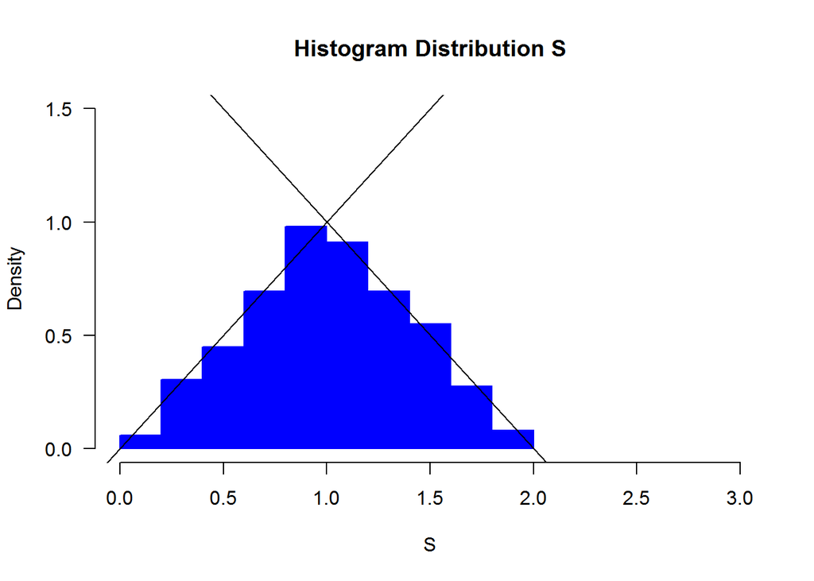

```r
# Plot the histogram
hist(S,
     main = "Histogram Distribution S",
     xlab = "S",
     border = "blue",
     col = "blue",
     xlim=c(0,3),
     ylim=c(0,1.5),
     las = 1,
     breaks = 10,
     probability = TRUE)


# Add the density function curve with lines
abline(0,1)
abline(2,-1)
```

Then, Obtain the continuous distribution function, by taking the integral of the density function.

Then obtain the probability of B + C < 1/2

```r
# integrate the density function
integration1 <- function(x){x}

probability1 <- integrate(integration1, lower = 0, upper = 1/2)
# probability B + C < 1/2:
probability1
```

```
## 0.125 with absolute error < 1.4e-15
```

** (B) BC < 1/2 **

```r
# Create a set of random numbers between 0 to 1 for B and C
B2 <- runif(1000, min = 0, max = 1)
C2 <- runif(1000, min = 0, max = 1)

# S2
S2 <- B2 * C2
```

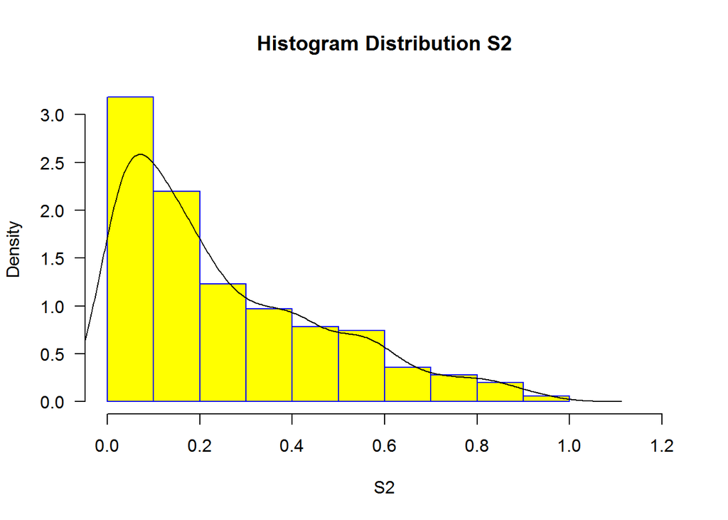

```r
# Plot the histogram
hist2 <- hist(S2,
     main = "Histogram Distribution S2",
     xlab = "S2",
     border = "blue",
     col = "yellow",
     xlim=c(0,1.2),
     las = 1,
     breaks = 10,
     probability = TRUE)

# Add density curve to the histogram
lines(density(S2))
```

```r
# Add the first five bins (< .5) to get area. This is probability of B * C < 1/2
# height x width
probability2 <- sum(hist2$density[1:5]*.1)

# probability of BC < 1/2
probability2
```

```
## [1] 0.836
```

```r
# [1] 0.841
```

** (C) |B - C| < 1/2 **

```r
# Create a set of random numbers between 0 to 1 for B and C
B3 <- runif(1000, min = 0, max = 1)
C3 <- runif(1000, min = 0, max = 1)

# S3
S3 <- abs(B3 - C3)
```

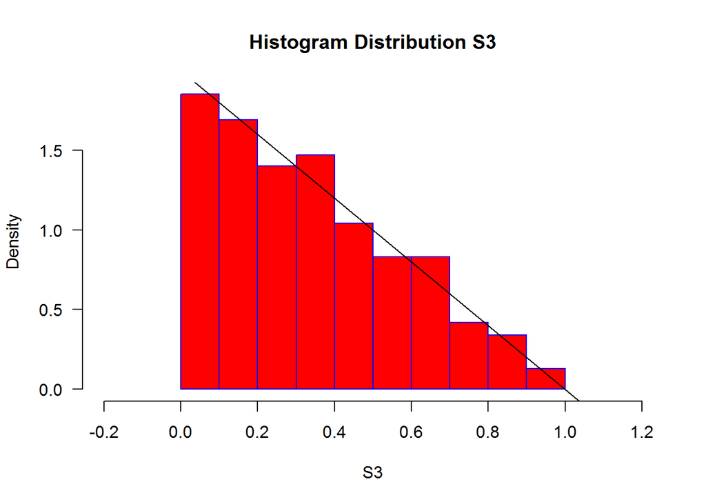

```r
# Historgram plot
hist3 <- hist(S3,
     main = "Histogram Distribution S3",
     xlab = "S3",
     border = "blue",
     col = "red",
     xlim=c(-.2,1.2),
     las = 1,
     breaks = 10,
     probability = TRUE)

# Add a density function line to fit
abline(2,-2)
```

Integrate the function obtained above.

```r
# integrate the density function
integration3 <- function(x){2-2*x}

# Obtain the probability of |B - C| < 1/2
probability3 <- integrate(integration3, lower = 0, upper = 0.5)

# Probability of |B - C| < 1/2
probability3
```

```
## 0.75 with absolute error < 8.3e-15
```

```r
#0.75 with absolute error < 8.3e-15
```

** (D) max{B,C} < 1/2 **

```r
# Create a set of random numbers between 0 to 1 for B and C
B4 <- runif(1000, min = 0, max = 1)
C4 <- runif(1000, min = 0, max = 1)

# S4
S4 <- pmax(B4, C4)
```

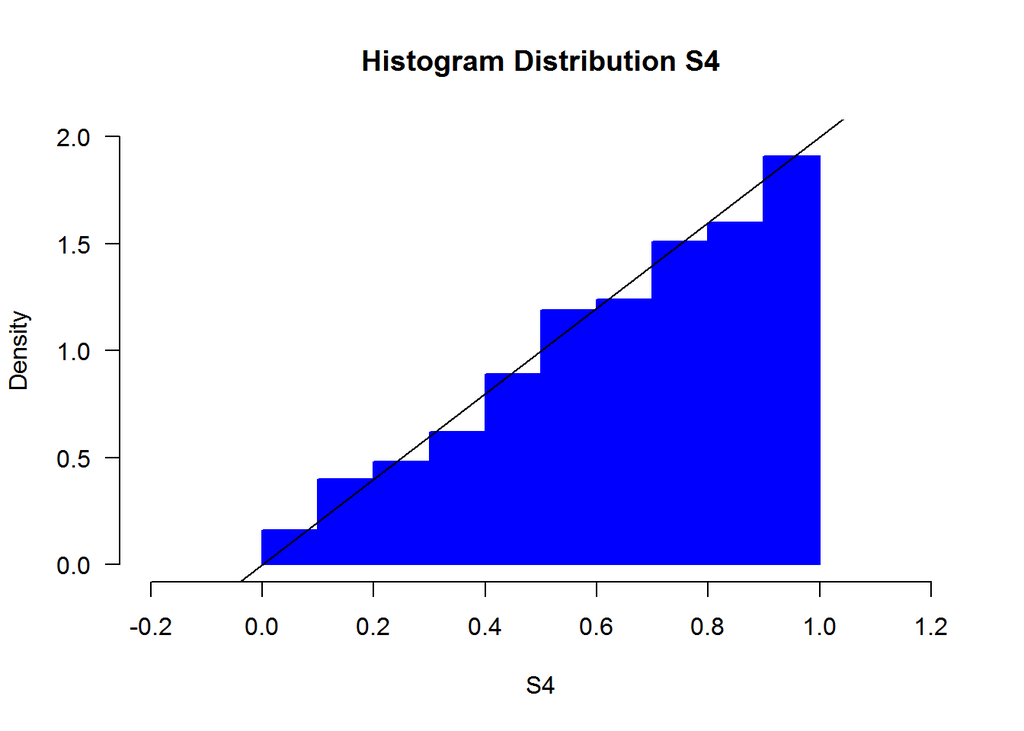

```r
# Creating a histogram S4
hist4 <- hist(S4,
     main = "Histogram Distribution S4",
     xlab = "S4",
     border = "blue",
     col = "blue",
     xlim=c(-.2,1.2),
     ylim=c(0, 2),
     las = 1,
     breaks = 10,
     probability = TRUE)

# Add a density function to fit
abline(0,2)
```

Integrate the function obtained above.

```r
# integrate the density function
integration4 <- function(x){2*x}

# Obtain the probability of max{B,C} < 1/2
probability4 <- integrate(integration4, lower = 0, upper = 0.5)

# probability of max{B,C} < 1/2
probability4
```

```
## 0.25 with absolute error < 2.8e-15
```

** (E) min{B,C} < 1/2 **

```r
# Create a set of random numbers between 0 to 1 for B and C
B5 <- runif(1000, min = 0, max = 1)
C5 <- runif(1000, min = 0, max = 1)

# S4
S5 <- pmin(B5, C5)
```

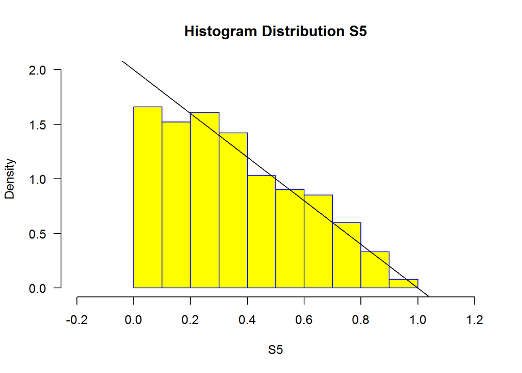

```r
# Creating a histogram for Z5
hist5 <- hist(S5,
     main = "Histogram Distribution S5",
     xlab = "S5",
     border = "blue",
     col = "yellow",
     xlim=c(-.2,1.2),
     ylim=c(0,2),
     las = 1,
     breaks = 10,
     probability = TRUE)

# Add a density function to fit
abline(2,-2)
```

Integrate the function obtained above.

```r
# integrate the density function
integration5 <- function(x){2-2*x}

# Obtain the probability of min{B,C} < 1/2
probability5 <- integrate(integration5, lower = 0, upper = 0.5)

# probability of min{B,C} < 1/2
probability5
```

```
## 0.75 with absolute error < 8.3e-15
```

```r
# 0.75 with absolute error < 8.3e-15
```

**END**